# Explore DM Genes

Coleman Breen

2023-03-01

## Summary

1. At lFDR of 0.01, there are 2808 genes that are DM

# Basic Questions and Summaries

How many genes tested (one or more CpGs)? About 19,000

```
## [1] 18858
```

## Calibration of Harmonic Mean P-values

It’s not perfect, but much better than Fisher’s method.

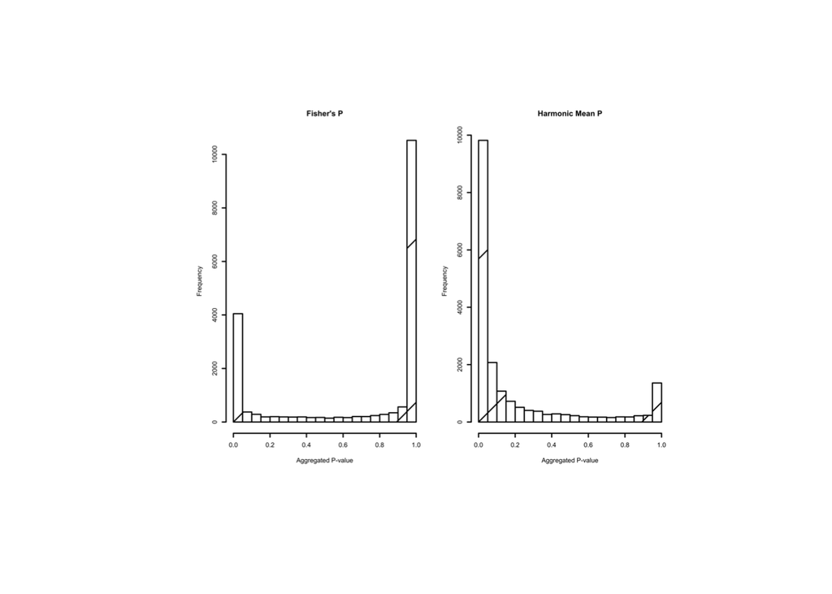

# How many significant genes based on Bonferroni and FDR?

## Bonferroni

First, let’s look at Bonferroni.

```
## [1] 593
```

```
## [1] 453
```

Bonferroni correction at level 0.05 and 0.01 give 593 and 453 significant genes respectively.

## FDR

There are ~7,600 and 2,800 significant at lFDR of 0.05 and 0.01.

```
## [1] 7579
```

```
## [1] 2808
```

## Is there any realtionship between gene length and lFDR?

This could occur if Harmonic P-value is not sufficiently accounting for dependency structure.

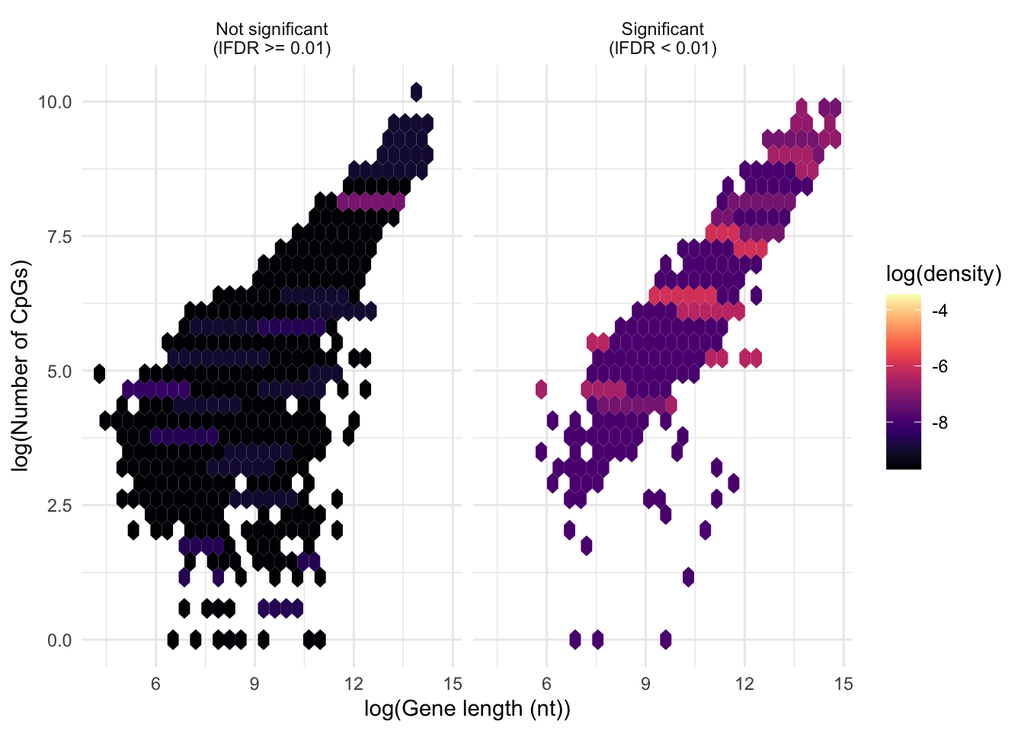

There could be a small difference between the non-significant and significant distributions of gene length (x-axis) or number of CpGs (y-axis).

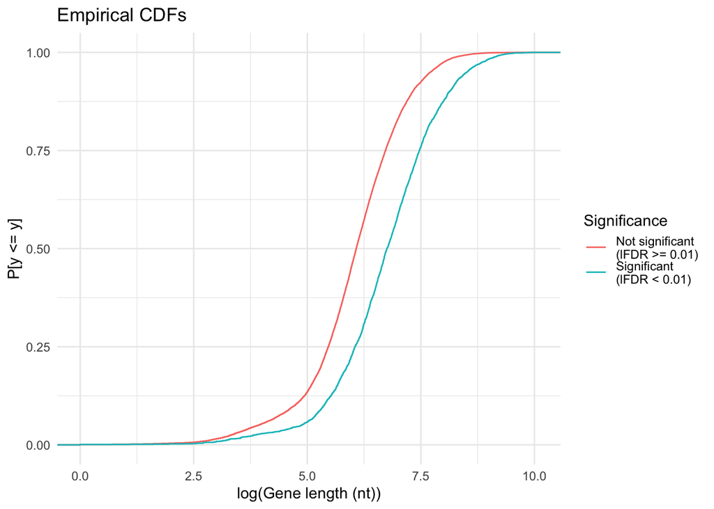

There are relatively more short genes in the not significant group–this could be biological, but could be artefactual of harmonic p-value combination method.

# Gene Ontology for LFDR 0.01

What are the gene ontologies here?

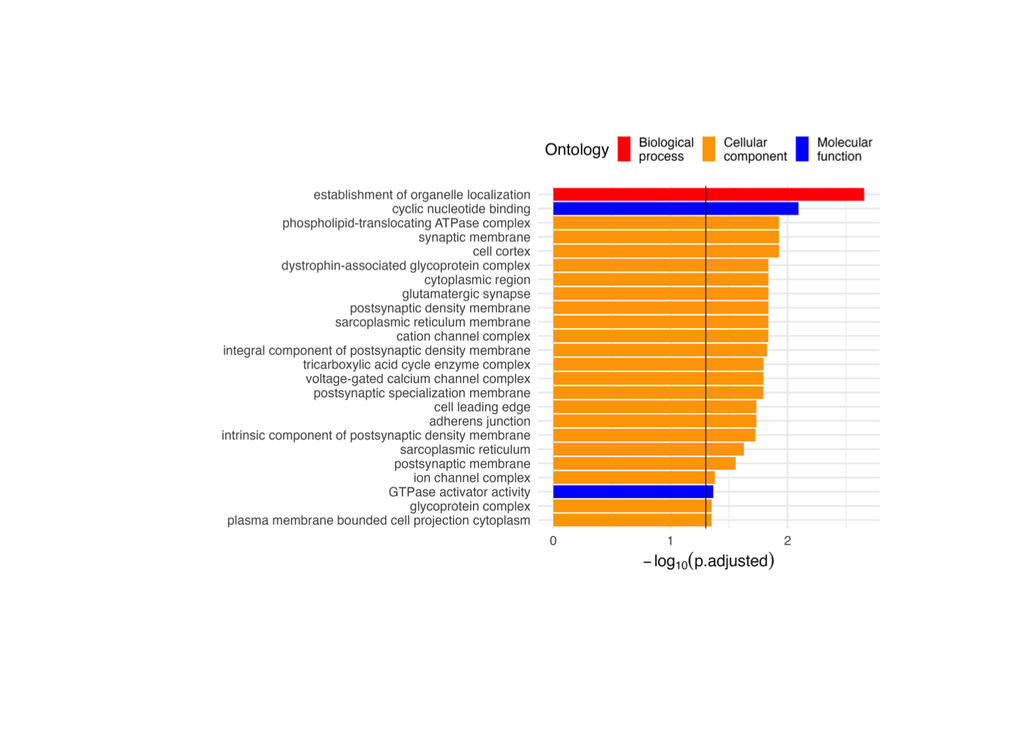

# Do these overlap with GWAS?

See [this paper](https://doi.org/10.1038/s41588-022-01024-z) for a list of GWAS genes.

## Overlaps with GWAS genes

```
##          No.Set1 Yes.Set1
## No.Set2    15992       61
## Yes.Set2    2788       17
```

```
##
##  Pearson's Chi-squared test
##
## data:  tb
## X-squared = 2.9626, df = 1, p-value = 0.08521
```

There are 17 genes that are in both lists.

```
##  [1] "ABCA1"    "ANK3"     "CASS4"    "EED"      "EPDR1"    "HLA-DQA1"
##  [7] "IL34"     "KLF16"    "LILRB2"   "MME"      "PLEKHA1"  "RHOH"
## [13] "SLC24A4"  "TREML2"   "UMAD1"    "UNC5CL"   "USP6NL"
```

# Differential Expression (Not fleshed out)

```
##          No.Set1 Yes.Set1
## No.Set2    15302     2710
## Yes.Set2     751       95
```

```
##
##  Pearson's Chi-squared test
##
## data:  tb
## X-squared = 9.294, df = 1, p-value = 0.002299
```

There are 95 genes that are both DM and DE.

# Citations

Bellenguez, C., Küçükali, F., Jansen, I.E. et al. New insights into the genetic etiology of Alzheimer’s disease and related dementias. Nat Genet 54, 412–436 (2022). https://doi.org/10.1038/s41588-022-01024-z